# Laboratory Task 5

### DS4A - DS413

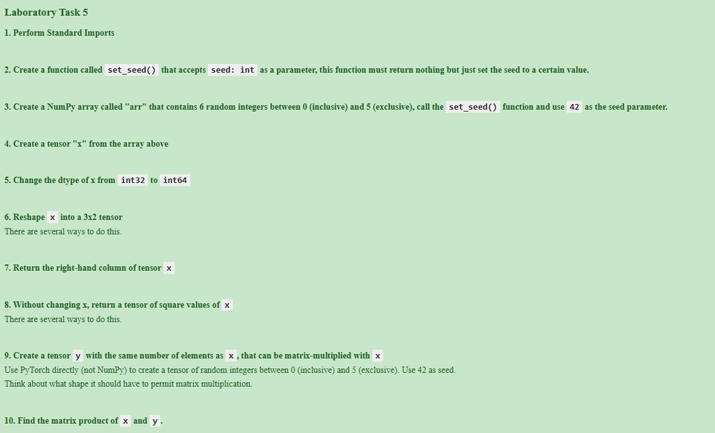

```python
from IPython.display import Image, display
display(Image(filename="Laboratory Task 5.png"))
```

**1. Perform Standard Imports**

```python
import torch
import numpy as np
import sys
```

**2. Create a function called set_seed() that accepts seed: int as a parameter, this function must return nothing but just set the seed to a certain value.**

```python
def set_seed(seed: int):
    """Sets the seed for NumPy and PyTorch for reproducibility."""
    np.random.seed(seed)
    torch.manual_seed(seed)
```

**3. Create a NumPy array called "arr" that contains 6 random integers between 0 (inclusive) and 5 (exclusive), call the set_seed() function and use 42 as the seed parameter.**

```python
set_seed(42) # Set seed for reproducibility
arr = np.random.randint(0, 5, size=6, dtype=np.int32)
arr
```

```
array([3, 4, 2, 4, 4, 1], dtype=int32)
```

```python
print(f"3. NumPy array 'arr' (Shape: {arr.shape}, Dtype: {arr.dtype}): {arr}")
```

```
3. NumPy array 'arr' (Shape: (6,), Dtype: int32): [3 4 2 4 4 1]
```

**4. Create a tensor "x" from the array above**

```python
x = torch.from_numpy(arr)
print(f"4. Tensor 'x' (Shape: {x.shape}, Dtype: {x.dtype}): {x}")
x
```

```
4. Tensor 'x' (Shape: torch.Size([6]), Dtype: torch.int32): tensor([3, 4, 2, 4, 4, 1], dtype=torch.int32)
```

```
tensor([3, 4, 2, 4, 4, 1], dtype=torch.int32)
```

**5. Change the dtype of x from int32 to int64**

```python
x = x.to(torch.int64) # or x.long()
print(f"5. Tensor 'x' (New Dtype: {x.dtype}): {x}")
x
```

```
5. Tensor 'x' (New Dtype: torch.int64): tensor([3, 4, 2, 4, 4, 1])
```

```
tensor([3, 4, 2, 4, 4, 1])
```

**6. Reshape x into a 3x2 tensor**

```python
# Method 1: .view()
x = x.view(3, 2)
print(f"6. Reshaped tensor 'x' (Shape: {x.shape}): \n{x}")
x
```

```
6. Reshaped tensor 'x' (Shape: torch.Size([3, 2])):
tensor([[3, 4],
        [2, 4],
        [4, 1]])
```

```
tensor([[3, 4],
        [2, 4],
        [4, 1]])
```

```python
# Method 2: .reshape()
x = x.reshape(3, 2)
print(f"6. Reshaped tensor 'x' (Shape: {x.shape}): \n{x}")
x
```

```
6. Reshaped tensor 'x' (Shape: torch.Size([3, 2])):
tensor([[3, 4],
        [2, 4],
        [4, 1]])
```

```
tensor([[3, 4],
        [2, 4],
        [4, 1]])
```

**7. Return the right-hand column of tensor x**

```python
# Slicing: all rows (:) and the last column (index 1 or -1)
right_column = x[:, 1]
print(f"7. Right-hand column (Shape: {right_column.shape}): \n{right_column}")
```

```
7. Right-hand column (Shape: torch.Size([3])):
tensor([4, 4, 1])
```

**8. Without changing x, return a tensor of square values of x**

```python
# Element-wise operation using ** or .pow()
x_squared = x ** 2
print(f"8. Tensor of square values (Shape: {x_squared.shape}): \n{x_squared}")
print(f"8. Original x unchanged: {x}")
```

```
8. Tensor of square values (Shape: torch.Size([3, 2])):
tensor([[ 9, 16],
        [ 4, 16],
        [16,  1]])
8. Original x unchanged: tensor([[3, 4],
        [2, 4],
        [4, 1]])
```

**9. Create a tensor y with the same number of elements as x, that can be matrix-multiplied with x. Use PyTorch directly (not NumPy) to create a tensor of random integers between 0 (inclusive) and 5 (exclusive). Use 42 as seed. Think about what shape it should have to permit matrix multiplication.**

```python
# x is (3x2). For matrix multiplication (x @ y), y must be (2 x N).
# The simplest shape with 6 elements that can be multiplied is (2x3).

set_seed(42) # Re-setting the seed, as requested, before creating y
y = torch.randint(0, 5, size=(2, 3), dtype=torch.int64)
print(f"9. Tensor 'y' (Shape: {y.shape}, Dtype: {y.dtype}): \n{y}")
```

```
9. Tensor 'y' (Shape: torch.Size([2, 3]), Dtype: torch.int64):
tensor([[2, 2, 1],
        [4, 1, 0]])
```

**10. Find the matrix product of x and y.**

```python
z = x @ y
print(f"10. Matrix product z = x @ y (Shape: {z.shape}): \n{z}")
```

```
10. Matrix product z = x @ y (Shape: torch.Size([3, 3])):
tensor([[22, 10,  3],
        [20,  8,  2],
        [12,  9,  4]])
```